# Python数据处理

## 06. 文本编码和正则表达式

主讲人：丁平尖

## 结构化数据

- 存储：存储介质上的位（例如，硬盘）
  - 编码：位如何对应符号？
  - 解释/含义：例如，字符组合成单词
  - 分隔文件：单词组合成句子，文档
  - 结构化内容：元数据，标签等
  - 集合：数据库，目录，归档（.zip，.gz，.tar等）

## 文本数据无处不在

例子：

- 生物统计学（DNA/RNA/蛋白质序列
  - 5'- AUGCGUAUGCUACGCUAGCUUGCUAGCU -3'
- 数据库（例如，人口普查数据，产品库存）
- 日志文件（程序名称，IP地址，用户ID等）
- 医疗记录（病例历史，医生的笔记，药物清单）
- 社交媒体（Facebook，Twitter等）

## 文本数据是如何存储的？

- 基本上，计算机上的每个文件只是一串位
  - 0 1 1 0 0 0 1 1 0 1 1 0 0 0 0 1 0 1 1 1 0 1 0 0
- 这些位被分成（例如）字节
  - 0 1 1 0 0 0 1 1 0 1 1 0 0 0 0 1 0 1 1 1 0 1 0 0
  - 这些字节对应于（在文本的情况下）字符。
  - 0 1 1 0 0 0 1 1 0 1 1 0 0 0 0 1 0 1 1 1 0 1 0 0
  - c a t

## 文本数据是如何存储的？

- 一些编码（例如，UTF-8和UTF-16）使用“可变长度”编码，不同的字符可能使用不同数量的字节。
- 我们今天会专注于ASCII，它使用固定长度编码。
  - 0 1 1 0 0 0 1 1 0 1 1 0 0 0 0 1 0 1 1 1 0 1 0 0
  - c a t

## ASCII（美国信息交换标准代码）

- 8位*固定长度编码，文件存储为字节流
- 每个字节编码一个字符
  - 字母，数字，符号或“特殊”字符（例如，制表符，换行符，NULL）
- 分隔符：一个或多个字符，用于指定边界
  - 例如：空格（‘ ’，ASCII 32），制表符（‘\t’，ASCII 9），换行符（‘\n’，ASCII 10）
  - [https://en.wikipedia.org/wiki/ASCII\](https://en.wikipedia.org/wiki/ASCII%5C)
- 技术上，每个ASCII字符是7位，第8位保留用于错误检查

## ASCII 表格

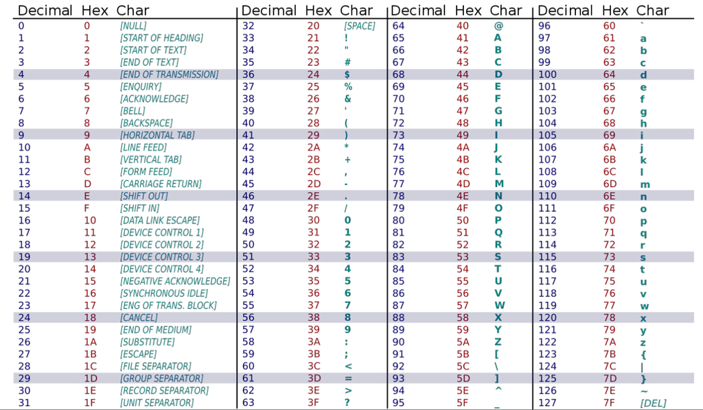

## 注意！

- 不同的操作系统在保存文本文件时遵循略微不同的约定！
- 最常见的问题：
  - UNIX/Linux/MacOS：换行符存储为`\n`
  - DOS/Windows：存储为`\r\n`（回车，然后换行）

## Unicode

- 几乎所有世界书写系统的通用编码
- 每个符号被分配一个唯一的代码点，一个四位十六进制数字
  - 给定字符U+XXXX分配给唯一数字
  - ‘U+’表示unicode，XXXX是代码点（十六进制）
  - 例如：∰=U+2230；http://www.unicode.org/ 了解更多
- 可变长度编码
  - UTF-8：前128个代码点使用1个字节，更高代码点使用2个或更多字节
  - 结果：ASCII是UTF-8的子集
- Python 3+版本默认编码脚本为unicode

## 匹配文本：正则表达式（“regexes”）

- 假设我想在一个大文本文件中找到所有地址。怎么做？
- 正则表达式允许在文本中匹配模式的简洁规范

## Python中的正则表达式：re包

- 三个基本功能：
  - re.match（）：尝试在字符串开头应用正则表达式。
  - re.search（）：尝试匹配字符串的任何部分的正则表达式。
  - re.findall（）：在字符串中找到所有匹配模式的实例。
- 查看 https://docs.python.org/3/library/re.html 了解更多信息和更多功能（例如，分割和替换）。
- 简要介绍：https://docs.python.org/3/howto/regex.html#regex-howto

```python
import re
help(re.match)
```

```
Help on function match in module re:

match(pattern, string, flags=0)
    Try to apply the pattern at the start of the string, returning
    a Match object, or None if no match was found.
```

```python
# 模式匹配字符串1的开头，并返回匹配对象。
pat = 'cat'
string1 = 'cat on mat'
string2 = 'raning cats and dogs'
re.match(pat, string1)
```

```
<re.Match object; span=(0, 3), match='cat'>
```

```python
# 模式匹配字符串2，但不在开头，因此匹配失败并返回None。
re.match(pat, string2) is None
```

```
True
```

```python
help(re.search)
```

```
Help on function search in module re:

search(pattern, string, flags=0)
    Scan through string looking for a match to the pattern, returning
    a Match object, or None if no match was found.
```

```python
# 模式匹配字符串1的开头，并返回匹配对象。
pat = 'cat'
string1 = 'cat on mat'
string2 = 'raining cats and dogs'
string3 = 'abracadabra'
re.search(pat, string1)
```

```
<re.Match object; span=(0, 3), match='cat'>
```

```python
# 模式匹配字符串2（不在开头！）并返回匹配对象。
re.search(pat, string2)
```

```
<re.Match object; span=(8, 11), match='cat'>
```

```python
# 模式在字符串3中不匹配任何内容，返回None。
re.search(pat, string3) is None
```

```
True
```

```python
help(re.findall)
```

```
Help on function findall in module re:

findall(pattern, string, flags=0)
    Return a list of all non-overlapping matches in the string.

    If one or more capturing groups are present in the pattern, return
    a list of groups; this will be a list of tuples if the pattern
    has more than one group.

    Empty matches are included in the result.
```

```python
# 模式在字符串1中匹配一次，返回该匹配。
pat = 'cat'
string1 = 'cat on mat'
string2 = 'one cat, two cats, three cats'
string3 = 'abracadabra'
re.findall(pat, string1)
```

```
['cat']
```

```python
# 模式在字符串2中匹配三次；返回三个实例的列表。
re.findall(pat, string2)
```

```
['cat', 'cat', 'cat']
```

```python
# 模式在字符串3中不匹配任何内容，返回空列表。
re.findall(pat, string3)
```

```
[]
```